# Geostats I

Maggy Critchlow

5/23/2020

## Data Overview

This data set represents monthly precipitation in millimeters, along with a annual average, from 432 data collection stations across California. While this is a large amount of data, we do not currently have precipitation values for every single area of the state. Fortunately, it’s possible to interpolate the missing values, and one method is inverse distance weighing (IDW), demonstrated below.

```r
bndCA <- readRDS("bndCA.rds")
gridCA <- readRDS("gridCA.rds")
precipCA <- readRDS("prcpCA.rds")
summary(precipCA$ANNUAL)
```

```
##    Min. 1st Qu.  Median    Mean 3rd Qu.    Max.
##    37.2   312.3   485.4   613.2   855.6  2337.0
```

### Packages Required

```r
library(ggplot2)
library(gstat)
library(sp)
library(sf)
```

### Map of Precipitation Data

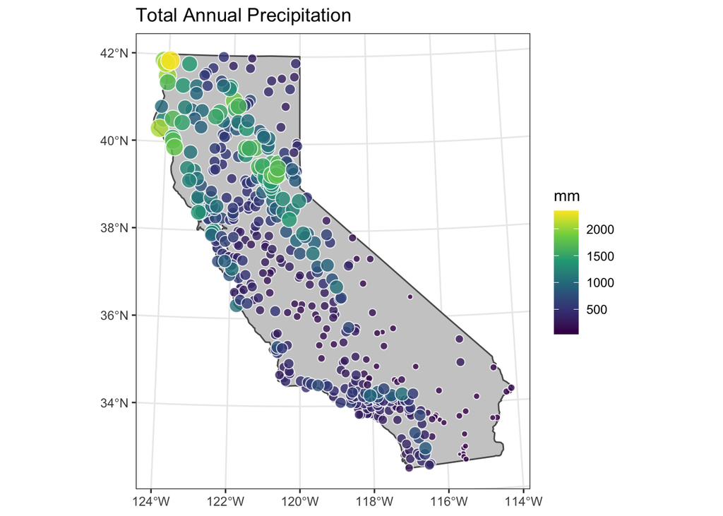

```r
plot1 <- ggplot() + geom_sf(data = bndCA, fill = "grey80") + geom_sf(data = precipCA, aes(fill = ANNUAL, size = ANNUAL), color = "white", shape=21, alpha=0.8) + scale_fill_continuous(type = "viridis", name = "mm") + guides(fill = guide_colorbar(), size="none") + labs(title="Total Annual Precipitation") + theme_bw()
plot1
```

The overall pattern is a higher volume of precipitation in the northwest corner of the state. The northern half of the state shows more precipitation than the southern half, and the southeastern area of the state has the lowest amounts. In terms of data availability, there are more precipitation values available for the western portion of the state, which makes sense when considering the population density of the state. There seem to be some significant gaps in coverage in eastern California, especially between Death Valley and the Mojave National Preserve. These areas will likely be the weakest part of the model, since IDW performs best with a denser data set.

## Predictions via Inverse Distance Weighting

### Testing and Training Separation

In checking a model’s gooness of fit, it is important to include testing data for the model. Withholding 10% of the data is somewhat arbitrary, but seems to strike a good balance between providing enough data to build a good model, yet hold back enough data to ensure a robust test. Cross-validation will be useful in determining the best amount of data to withhold.

```r
precipCA.sp <- as_Spatial(precipCA)
n <- nrow(precipCA)
testrows <- sample(x = 1:n, size = n*0.1)
cal.test <- precipCA.sp[testrows,]
cal.train <- precipCA.sp[-testrows,]
```

### IDW with Power of 2

```r
cal.IDW <- idw(formula = ANNUAL~1, locations = cal.train, newdata = gridCA, idp = 2)
```

```
## [inverse distance weighted interpolation]
```

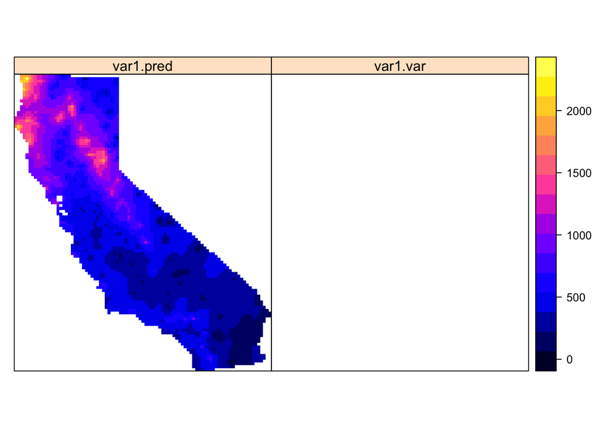

```r
spplot(cal.IDW)
```

This map has some spots that don’t appear to blend in well with the rest of the data, such as the “craters” towards the southern-center part of the state. When used along with the model’s RMSE and R<sup>2</sup>, this could suggest that this model is not the best fit for this data.

#### Residual Means Squared Error and R<sup>2</sup>

```r
obs <- cal.test@data$ANNUAL
tmp <- over(cal.test, cal.IDW)
preds <- tmp$var1.pred
rsq <- round(cor(obs,preds,use = "complete.obs")^2,digits = 3)
rmse <- round(sqrt(mean((preds - obs)^2, na.rm=TRUE)))
rsq
```

```
## [1] 0.79
```

```r
rmse
```

```
## [1] 175
```

Using a squared weighting value provides a model with an R<sup>2</sup> value of 0.79, and a RMSE of 175, when compared against the test data. This R<sup>2</sup> value is generally interpreted as a well-fitting model, but perhaps there’s an even better fit out there with a different exponent.

#### Linear Regression

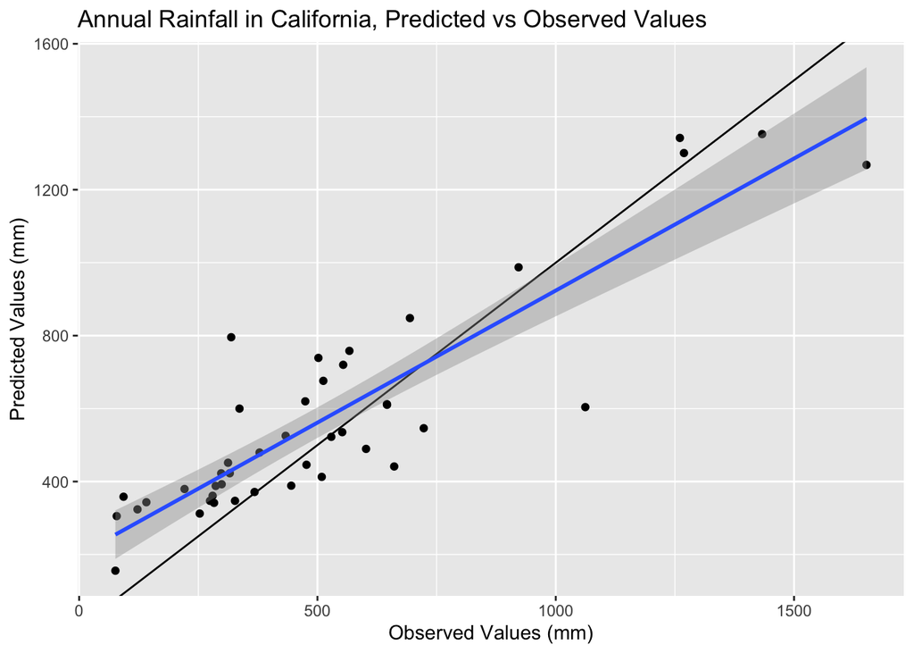

```r
plot2 <- ggplot()  + geom_abline(slope=1,intercept = 0) + geom_point(aes(x=obs,y=preds)) + geom_smooth(aes(x=obs,y=preds),method ="lm") + labs(x="Observed Values (mm)",y="Predicted Values (mm)",title="Annual Rainfall in California, Predicted vs Observed Values")
plot2
```

### IDW with Power of 4 and 5 Maximum Points

Using an iterative approach, I tested out various power integers to find the weighting that offered the highest R<sup>2</sup> and lowest RMSE. Ultimately, a power of four with five maximum points for interpolation performed the best by these metrics out of all attempts.

```r
cal.IDW4 <- idw(formula = ANNUAL~1, locations = cal.train, newdata = gridCA, idp = 4, nmax = 5)
```

```
## [inverse distance weighted interpolation]
```

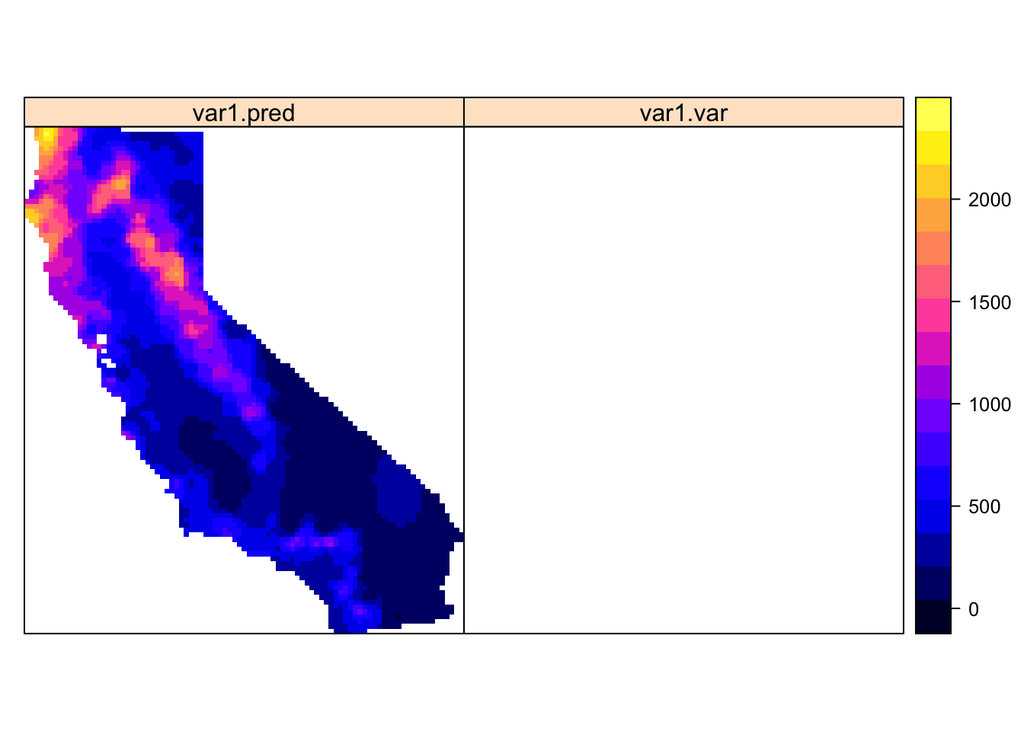

```r
spplot(cal.IDW4)
```

This map looks better than the one above, and is notably missing the mismatched spots. It seems to be a pretty good fit.

#### RMSE and R<sup>2</sup>

```r
tmp4 <- over(cal.test, cal.IDW4)
preds4 <- tmp4$var1.pred
rsq4 <- round(cor(obs, preds4, use = "complete.obs")^2, digits = 3)
rmse4 <- round(sqrt(mean((preds4 - obs)^2, na.rm=TRUE)))
rsq4
```

```
## [1] 0.852
```

```r
rmse4
```

```
## [1] 144
```

The R<sup>2</sup> value of 0.852 indicates a model that fits the data well and is quite accurate when predicting the data based on the comparison with the observed test data. A power of 4 also has a lower RMSE, which shows less unexplained variance in the data between the predicted and observed test values. Without trying fractions as powers, it’s difficult to say if this is the “best” model for this data. Due to the sparse coverage in parts of the state, and the scatter of points towards the middle of the regression, this may be the best-fitting model that’s possible to achieve using this method.

#### Linear Regression

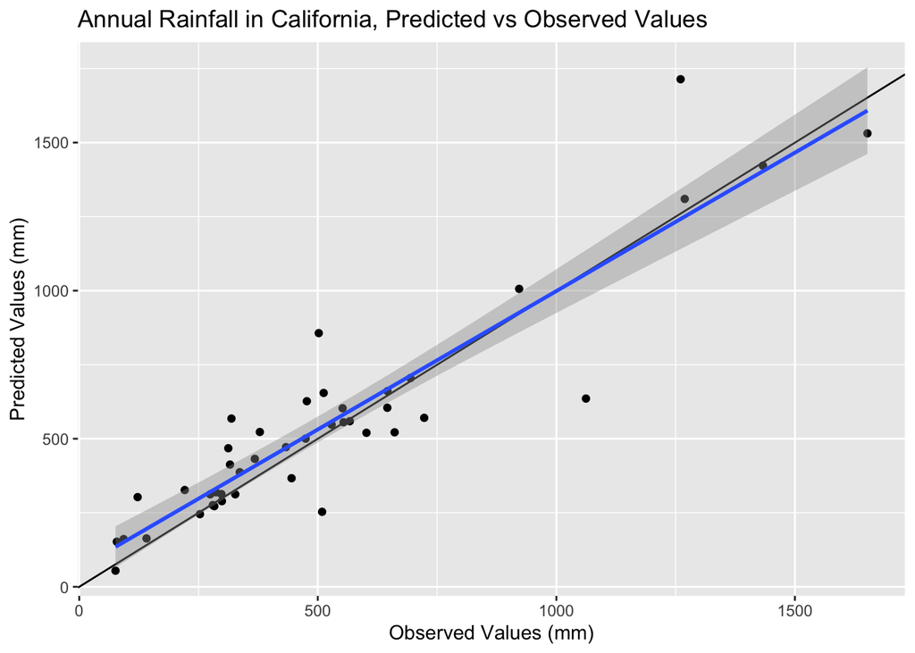

```r
plot4 <- ggplot()  + geom_abline(slope = 1, intercept = 0) + geom_point(aes(x = obs, y = preds4)) + geom_smooth(aes(x = obs, y = preds4), method = "lm") + labs(x = "Observed Values (mm)", y = "Predicted Values (mm)", title = "Annual Rainfall in California, Predicted vs Observed Values")
plot4
```